# polynomial_regression_model_housing_data

```python
import pandas as pd
import numpy as np
import matplotlib.pyplot as plt
% matplotlib inline
from sklearn.base import BaseEstimator, TransformerMixin
from sklearn.pipeline import Pipeline
from sklearn.linear_model import SGDRegressor
from sklearn.metrics import mean_squared_error, r2_score
from sklearn.preprocessing import PolynomialFeatures
from sklearn.preprocessing import MinMaxScaler
from sklearn.model_selection import GridSearchCV

plt.rcParams['axes.labelsize'] = 14
plt.rcParams['xtick.labelsize'] = 12
plt.rcParams['ytick.labelsize'] = 12
import warnings
warnings.filterwarnings('ignore')
```

```python
housing_train_set = pd.read_csv('../data/cleaned_housing_train_set.csv')
X_features  = [feature for feature in housing_train_set.columns if feature not in ['SalePrice', 'Id']]
y_feature = 'SalePrice'
```

```python
class InputOutputFeatureSelector(BaseEstimator, TransformerMixin):
    def __init__(self, in_attr_list, our_feature):
        self.in_attr_list = in_attr_list
        self.our_feature = our_feature
    def fit(self, X, y=None):
        return self
    def transform(self, X):
        return X[self.in_attr_list].values, X[self.our_feature].values
```

```python
def defineInOutPipeling(X_feat, y_feat):
    pipeline_inout_features = Pipeline([
        ('inputOutputFeatureSelector', InputOutputFeatureSelector(X_feat, y_feat))
    ])
    return pipeline_inout_features
```

```python
pipeline_inout_features = defineInOutPipeling(X_features, y_feature)
```

```python
X_train, y_train = pipeline_inout_features.fit_transform(housing_train_set)
```

```python
X_train.shape
```

```
(1149, 98)
```

```python
pipeline_min_max_scale = Pipeline([
    ('minMaxScaler', MinMaxScaler())
])
```

```python
X_train = pipeline_min_max_scale.fit_transform(X_train)
```

### Regularized Linear Models

- A good way to reduce overfitting or feature selection is to regularize the model (i.e., to constrain it).
- For a linear model, regularization is typically achieved by constraining the weights of the model. We will now look at Ridge Regression, Lasso Regression, and Elastic Net, which implement three different ways to constrain the weights.

### Ridge Regression

- Ridge Regression (also called Tikhonov regularization) is a regularized version of Linear Regression: a regularization term shown below is added to the cost function. \begin{equation*} J\left( \theta \right) = MSE\left( \theta \right) + \lambda \left(\frac{1}{2} \sum_{i=1}^n \theta_i^2 \right) \end{equation*}  
  This forces the learning algorithm reduce the model weights as small as possible, generalizes better on an unseen data. The hyperparameter **"lambda" (shrinkage parameter)** controls how much you want to regularize the model. When **"lambda"** is zero, the model is just a linear model.
- Theta-0 not needed to be regularized. if we difine W a vector of features from Theta-1 to Theta-n then the regularization term for Ridge is equal to \begin{equation*} \left(\frac{1}{2} ||W||^2 \right) \end{equation*}  
  where ∥ · ∥ 2 represents the **ℓ2** norm of the weight vector. For Gradient Descent, just add αw to the MSE gradient vector

### Lasso Regression

- **Least Absolute Shrinkage and Selection Operator** Regression is another regularized version of Linear Regression: just like Ridge Regression, it adds a regularization term to the cost function, but it uses the **ℓ1** norm of the weight vector. \begin{equation*} J\left( \theta \right) = MSE\left( \theta \right) + \lambda \left(\sum_{i=1}^n |\theta_i| \right) \end{equation*}  
  An important characteristic of Lasso Regression is that it tends to **completely eliminate the weights of the least important features (i.e., set them to zero)**.
- Theta-0 not needed to be regularized. if we difine W a vector of features from Theta-1 to Theta-n then the regularization term for Lasso is equal to \begin{equation*} \left(||W|| \right) \end{equation*}

### Elastic Net

- Elastic Net is a middle ground between Ridge Regression and Lasso Regression. The regularization term is a simple mix of both Ridge and Lasso’s regularization terms, and you can control the mix ratio r. When r = 0, Elastic Net is equivalent to Ridge Regression, and when r = 1, it is equivalent to Lasso Regression \begin{equation*} J\left( \theta \right) = MSE\left( \theta \right) + r \lambda \sum_{i=1}^n |\theta*i| + \frac{1-r}{2} \lambda \sum*{i=1}^n \theta_i^2 \end{equation*}
- **Note - 1 :** So when should you use Linear Regression, Ridge, Lasso, or Elastic Net? It is almost always preferable to have at least a little bit of regularization, so generally you should avoid plain Linear Regression. Ridge is a good default, but if you suspect that only a few features are actually useful, you should prefer Lasso or Elastic Net since they tend to reduce the useless features’ weights down to zero as we have discussed. In general, Elastic Net is preferred over Lasso since Lasso may behave erratically when the number of features is greater than the number of training instances or when several features are strongly correlated.
- **Note - 2 :**
  - Scikit-Learn package uses "Eta0" to represent "Learning Rate - Alpha in theory"
  - Scikit-Learn package uses "Alpha" to represent "Shrinkage Parameter - Lambda in theory" </font>

### Now let us reduce features using ElasticNet Regularization

```python
def calculateR2RMSE(X, y, model):
    pred_y = model.predict(X)
    mse_X =  mean_squared_error(y, pred_y)
    r2_X = r2_score(y, pred_y)
    return np.sqrt(mse_X), r2_X

def calcualteRsqure(X, y, model):
    pred_y = model.predict(X)
    r2_X = r2_score(y, pred_y)
    return r2_X
```

### Find best features by applying ElasticNet regularization

```python
from sklearn.linear_model import ElasticNet
param_grid = [
    {'alpha': np.linspace(0.01, 2, 100)}
  ]
elst_lm_model = ElasticNet()
elst_grid_search = GridSearchCV(elst_lm_model, param_grid, cv=5,
                           scoring='neg_mean_squared_error')
elst_grid_search.fit(X_train, y_train)
```

```
GridSearchCV(cv=5, error_score='raise',
       estimator=ElasticNet(alpha=1.0, copy_X=True, fit_intercept=True, l1_ratio=0.5,
      max_iter=1000, normalize=False, positive=False, precompute=False,
      random_state=None, selection='cyclic', tol=0.0001, warm_start=False),
       fit_params={}, iid=True, n_jobs=1,
       param_grid=[{'alpha': array([ 0.01  ,  0.0301, ...,  1.9799,  2.    ])}],
       pre_dispatch='2*n_jobs', refit=True, return_train_score=True,
       scoring='neg_mean_squared_error', verbose=0)
```

```python
print(elst_grid_search.best_params_)
print(elst_grid_search.best_estimator_)
```

```
{'alpha': 0.01}
ElasticNet(alpha=0.01, copy_X=True, fit_intercept=True, l1_ratio=0.5,
      max_iter=1000, normalize=False, positive=False, precompute=False,
      random_state=None, selection='cyclic', tol=0.0001, warm_start=False)
```

```python
elst_model = ElasticNet(alpha=0.01, copy_X=True, fit_intercept=True,
      l1_ratio=0.5, max_iter=1000, normalize=False, positive=False,
      precompute=False, random_state=None, selection='cyclic', tol=0.0001,
      warm_start=False)
elst_model.fit(X_train, y_train)
print(calculateR2RMSE(X_train, y_train, elst_model))
```

```
(31723.267536847041, 0.85088217456188442)
```

```python
print(elst_model.coef_.shape)
```

```
(98,)
```

#### The features with 0 coeffecients are of not much user.

```python
for (fet, coef) in zip(X_features, elst_model.coef_):
    if coef == 0:
        print(fet, coef)
```

```
BsmtQual 0.0
BsmtExposure 0.0
BsmtFinType1 0.0
BsmtFinType2 0.0
GarageType 0.0
GarageFinish 0.0
GarageQual 0.0
GarageCond 0.0
Neighborhood_Names 0.0
```

#### Select best features by eliminating these non-important features.

```python
best_features = [fet for (fet, coef) in zip(X_features, elst_model.coef_) if coef != 0 ]
len(best_features)
```

```
89
```

### Build a ploynomial regression modle with these best features and see how the model works.

```python
pipeline_best_inout_features = defineInOutPipeling(best_features, y_feature)
X_train_best, y_train_best = pipeline_best_inout_features.fit_transform(housing_train_set)
```

```python
X_train_best.shape
```

```
(1149, 89)
```

```python
pipeline_ploy_transform = Pipeline([
    ('polynomialFeatures', PolynomialFeatures(degree=2, include_bias=False))
])
```

```python
X_train_best_poly = pipeline_ploy_transform.fit_transform(X_train_best)
```

```python
X_train_best_poly.shape
```

```
(1149, 4094)
```

```python
X_train_best_poly = pipeline_min_max_scale.fit_transform(X_train_best_poly)
```

```python
param_grid = [
    {'n_iter': [25, 50],
    'eta0': [0.0001, 0.0003],
    'alpha': [0.0001, 0.0003],
    'penalty': ['elasticnet']}
  ]
grd_sgd_model = SGDRegressor(random_state=15)
grid_search = GridSearchCV(grd_sgd_model, param_grid, cv=5,
                           scoring='neg_mean_squared_error')
grid_search.fit(X_train_best_poly, y_train_best)
```

```
GridSearchCV(cv=5, error_score='raise',
       estimator=SGDRegressor(alpha=0.0001, average=False, epsilon=0.1, eta0=0.01,
       fit_intercept=True, l1_ratio=0.15, learning_rate='invscaling',
       loss='squared_loss', n_iter=5, penalty='l2', power_t=0.25,
       random_state=15, shuffle=True, verbose=0, warm_start=False),
       fit_params={}, iid=True, n_jobs=1,
       param_grid=[{'n_iter': [25, 50], 'eta0': [0.0001, 0.0003], 'alpha': [0.0001, 0.0003], 'penalty': ['elasticnet']}],
       pre_dispatch='2*n_jobs', refit=True, return_train_score=True,
       scoring='neg_mean_squared_error', verbose=0)
```

```python
grid_search.best_params_
```

```
{'alpha': 0.0001, 'eta0': 0.0003, 'n_iter': 50, 'penalty': 'elasticnet'}
```

```python
grid_search.best_estimator_
```

```
SGDRegressor(alpha=0.0001, average=False, epsilon=0.1, eta0=0.0003,
       fit_intercept=True, l1_ratio=0.15, learning_rate='invscaling',
       loss='squared_loss', n_iter=50, penalty='elasticnet', power_t=0.25,
       random_state=15, shuffle=True, verbose=0, warm_start=False)
```

```python
ploy_sgd_model = SGDRegressor(alpha=0.0001, average=False, epsilon=0.1, eta0=0.0003,
       fit_intercept=True, l1_ratio=0.15, learning_rate='invscaling',
       loss='squared_loss', n_iter=50, penalty='elasticnet', power_t=0.25,
       random_state=15, shuffle=True, verbose=0, warm_start=False)
ploy_sgd_model.fit(X_train_best_poly, y_train_best)
```

```
SGDRegressor(alpha=0.0001, average=False, epsilon=0.1, eta0=0.0003,
       fit_intercept=True, l1_ratio=0.15, learning_rate='invscaling',
       loss='squared_loss', n_iter=50, penalty='elasticnet', power_t=0.25,
       random_state=15, shuffle=True, verbose=0, warm_start=False)
```

```python
print(calculateR2RMSE(X_train_best_poly, y_train_best, ploy_sgd_model))
```

```
(32237.606803548777, 0.84600758777016183)
```

**Caution :** we have to apply pipeline.tranform only on TEST set. If we do pipeline.fit_transform will give unexpected (erroneous) results.

```python
housing_test_set= pd.read_csv('../data/cleaned_housing_test_set.csv')
X_test_best, y_test_best = pipeline_best_inout_features.transform(housing_test_set)
X_test_best_poly = pipeline_ploy_transform.transform(X_test_best)
X_test_best_poly = pipeline_min_max_scale.transform(X_test_best_poly)
```

```python
X_test_best_poly.shape
```

```
(288, 4094)
```

```python
print(calculateR2RMSE(X_test_best_poly, y_test_best, ploy_sgd_model))
```

```
(26725.018560908706, 0.84526082951707693)
```

### Try multiple polynomial degres and see how the model is behaving.

```python
def getPloyDegreeAndRMSE(X_train, y_train, X_test, y_test, ploy_degrees):

    train_rmse, test_rmse = [], []
    for deg in ploy_degrees:
        pipeline_ploy_scale_trans = Pipeline([
            ('polynomialFeatures', PolynomialFeatures(degree=deg, include_bias=False)),
            ('minMaxScaler', MinMaxScaler())
        ])
        ploy_sgd_model = SGDRegressor(alpha=0.0001, average=False, epsilon=0.1, eta0=0.0003,
               fit_intercept=True, l1_ratio=0.15, learning_rate='invscaling',
               loss='squared_loss', n_iter=50, penalty='elasticnet', power_t=0.25,
               random_state=15, shuffle=True, verbose=0, warm_start=False)

        X_train_poly = pipeline_ploy_scale_trans.fit_transform(X_train)
        ploy_sgd_model.fit(X_train_poly, y_train)

        train_rmse.append(calculateR2RMSE(X_train_poly, y_train, ploy_sgd_model))

        X_test_poly = pipeline_ploy_scale_trans.transform(X_test)
        test_rmse.append(calculateR2RMSE(X_test_poly, y_test, ploy_sgd_model))
    return train_rmse, test_rmse
```

```python
ploy_degrees=[1,2,3]
train_rmse_r2, test_rmse_r2 = getPloyDegreeAndRMSE(X_train_best, y_train_best, X_test_best, y_test_best, ploy_degrees)
print("train_rmse : ", train_rmse_r2)
print("test_rmse : ", test_rmse_r2)
```

```
train_rmse :  [(57949.627313681958, 0.50240612179507416), (32237.606803548777, 0.84600758777016183), (18649.455311201498, 0.9484645540818275)]
test_rmse :  [(44648.720153650567, 0.56810093659441341), (26725.018560908706, 0.84526082951707693), (22098.796452284863, 0.8941961486139226)]
```

```python
train_deg_rmse = zip(ploy_degrees, train_rmse_r2)
test_deg_rmse = zip(ploy_degrees, test_rmse_r2)
for deg, rmse in train_deg_rmse:
    print("On Train set {} degree ploy, the RMSE is : {}".format(deg,rmse[0]))

for deg, rmse in test_deg_rmse:
    print("On Test set {} degree ploy, the RMSE is : {}".format(deg,rmse[0]))
```

```
On Train set 1 degree ploy, the RMSE is : 57949.62731368196
On Train set 2 degree ploy, the RMSE is : 32237.606803548777
On Train set 3 degree ploy, the RMSE is : 18649.4553112015
On Test set 1 degree ploy, the RMSE is : 44648.72015365057
On Test set 2 degree ploy, the RMSE is : 26725.018560908706
On Test set 3 degree ploy, the RMSE is : 22098.796452284863
```

```python
train_rmse = [x[0] for x in train_rmse_r2]
print(train_rmse)
test_rmse = [x[0] for x in test_rmse_r2]
print(test_rmse)
```

```
[57949.627313681958, 32237.606803548777, 18649.455311201498]
[44648.720153650567, 26725.018560908706, 22098.796452284863]
```

### Learning curve

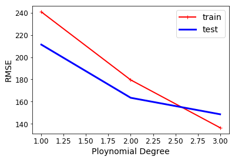

```python
plt.plot(ploy_degrees, np.sqrt(train_rmse), "r-+", linewidth=2, label="train")
plt.plot(ploy_degrees, np.sqrt(test_rmse), "b-", linewidth=3, label="test")
plt.legend(loc="upper right", fontsize=14)
plt.xlabel("Ploynomial Degree", fontsize=14)
plt.ylabel("RMSE", fontsize=14)
```